# projekt_zaliczeniowy

Adrianna Bukowska, Jagoda Szymczak

26 06 2020

# Analiza liczby rozwodów na terenie Polski w poszczególnych powiatach

Zainspirowane najpopularniejszym serialem wszech czasów - “Friends”, przykuła naszą uwagę postać Rosa Gellera - trzykrotnego rozwodnika. Ciekawi nas jak sytuacja wygląda w Polsce. Ile rozwodów przypada na 1000 mieszkańców? Jak na poziom ilości rozwodów wpływa wynagrodzenie? Poniżej przedstawiamy wyniki naszej analizy. Dane zostały pobrane z oficjalnej strony GUS (Bank Danych Lokalnych).

## Wizualizacja danych

### Liczba rozwodów w 2018 roku w poszczególnych powiatach

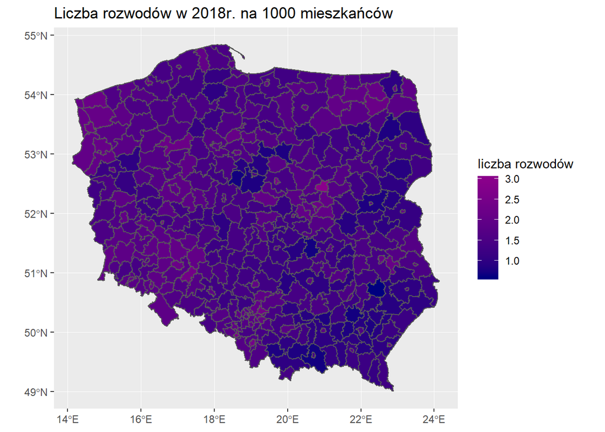

Najwięcej rozwodów na 1000 mieszkańców w 2018 roku przeprowadzono w powiecie legionowskim (3 rozwody na 1000 osób). Kolejne powiaty to: - m. Leszno (2,6/1000 os.) - m. Płock (2,5/1000 os.) - m. Jastrzębie-Zdrój (2,5/1000 os.) Najmniej rozwódów odnotowano w powiecie janowskim (0,6/1000 os.).

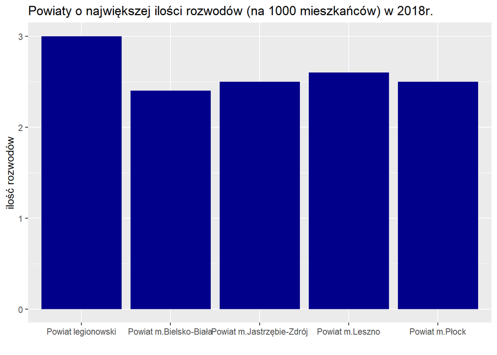

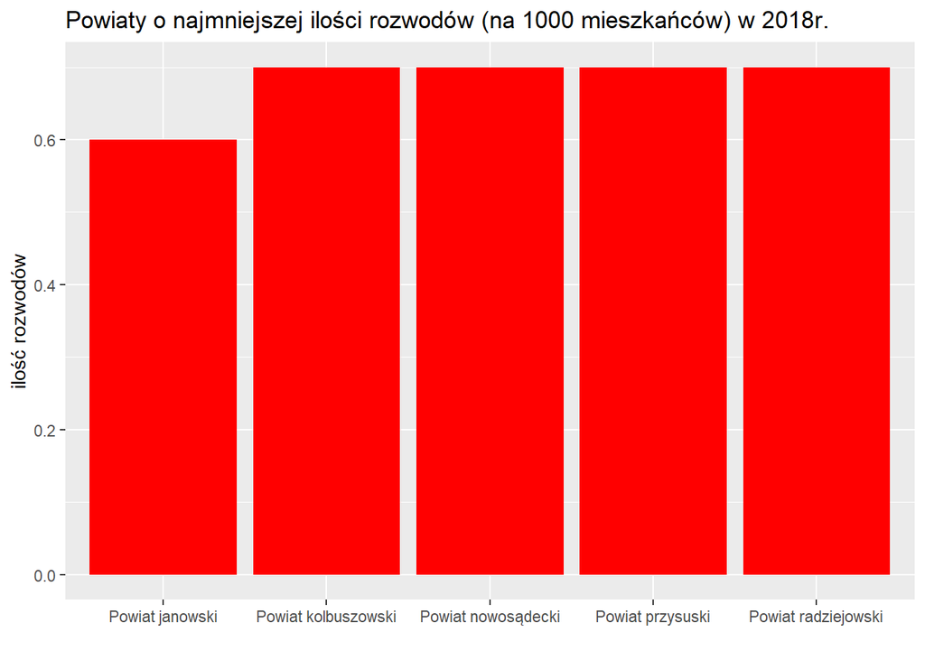

### Liczba rozwodów w 2019 roku w poszczególnych powiatach

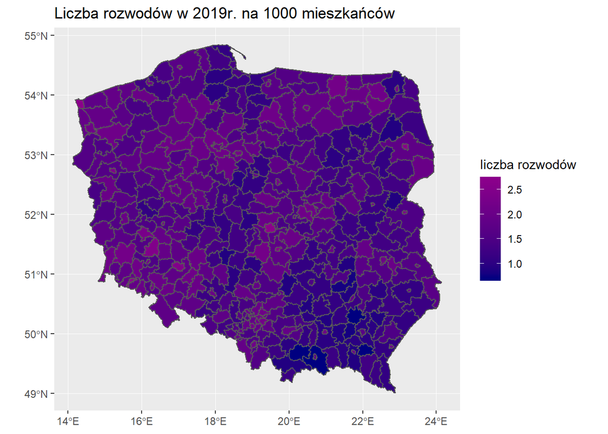

Najwięcej rozwodów na 1000 mieszkańców w 2019 roku przeprowadzono w powiatach: m. Jelenia Góra, m. Świnoujście i m. Łódź (po 2,7 rozwodów na 1000 osób). Najmniej rozwódów odnotowano w powiatach: brzozowskim, limanowskim, kolbuszowskim oraz nowosądeckim (0,7/1000 os.).

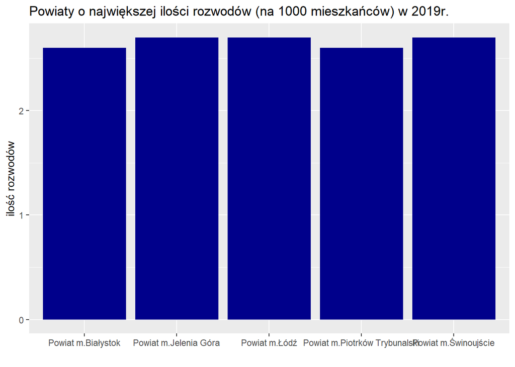

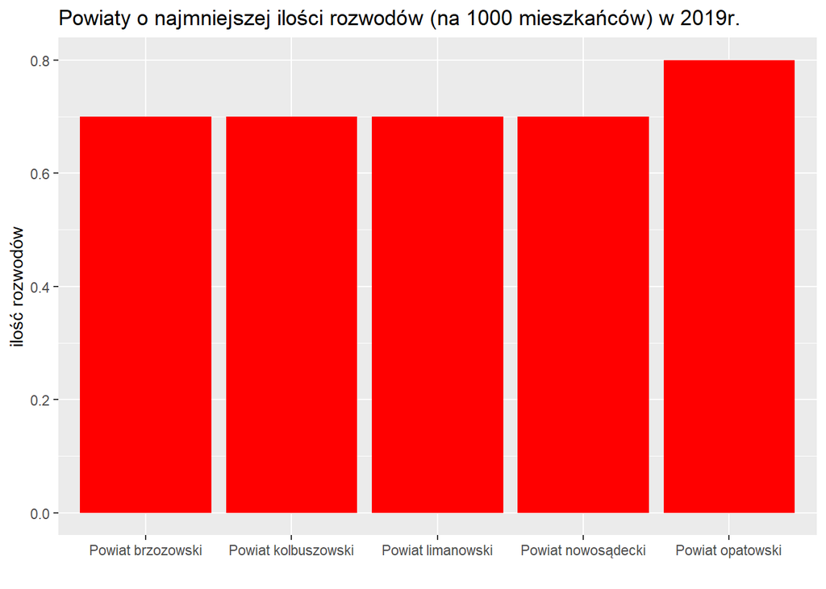

Na co dzień można się spotkać ze stwierdzeniem, że rozwody są tylko dla bogatych. Czy liczba rozwodów rzeczywiście zależy od zamożności obywateli?

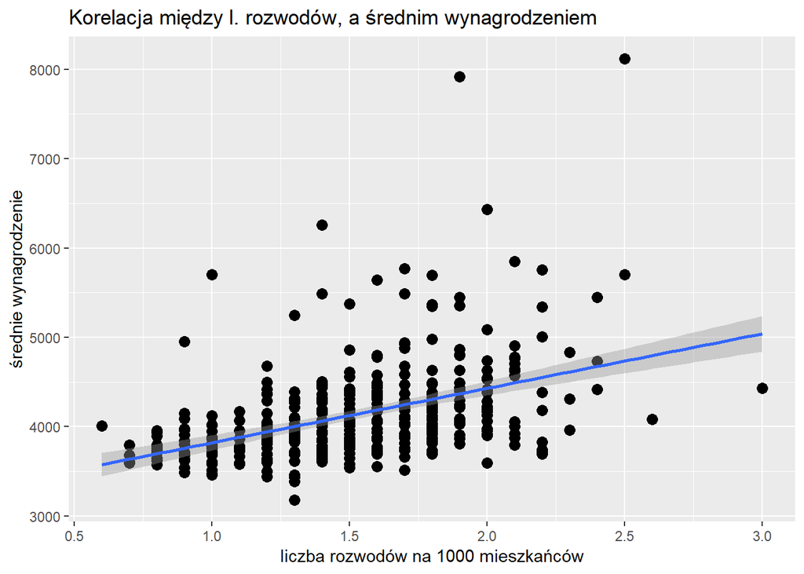

```
##
##  Pearson's product-moment correlation
##
## data:  kompletne_df$rozwody_2018 and kompletne_df$Wynagrodzenie_2018
## t = 9.1732, df = 378, p-value < 2.2e-16
## alternative hypothesis: true correlation is not equal to 0
## 95 percent confidence interval:
##  0.3407324 0.5056049
## sample estimates:
##       cor
## 0.4267074
```

W celu zbadania zależności między średnim wynagrodzeniem mieszkańców, a liczbą rozwodów, wykorzystany został współczynnik Pearsona. Jego wartość wynosi ok. 0,43, a więc zależność między zmiennymi jest raczej słaba. Znak przy współczynniku Pearsona jest dodatni, co oznacza, że im wyższe wynagrodzenie, tym wyższa liczba rozwodów. Ponadto, wyliczona p-wartość (p-value) jest mniejsza niż 0,05, co oznacza, iż zmienna objaśniająca (średnie wynagrodzenie) jest istotna.